# STAT/MATH 495: Problem Set 03

Jenn Halbleib

2017-09-26

# Question

For both `data1` and `data2` tibbles (a tibble is a data frame with some [metadata](https://blog.rstudio.com/2016/03/24/tibble-1-0-0#tibbles-vs-data-frames) attached):

- Find the splines model with the best out-of-sample predictive ability.
- Create a visualizaztion arguing why you chose this particular model.
- Create a visualizaztion of this model plotted over the given $(x_i, y_i)$ points for $i=1,\ldots,n=3000$.
- Give your estimate $\widehat{\sigma}$ of $\sigma$ where the noise component $\epsilon_i$ is distributed with mean 0 and standard deviation $\sigma$.

# Making a Function

First, I will define a function called “findDF”. This function takes a dataframe of 3 columns: ID, X, and Y and returns a table of degrees of freedom and the corresponding error determined by LOOCV when fitting a splines model to the data. The degrees of freedom are determined using “leave one out” cross-validation. Note: For this function to work properly, the column names must be ID, X, and Y.

Note: According to the documentation for smooth.spline(), the optimal degrees of freedom falls in the range from (1, nx) where nx is the number of unique x values in the data set. For simplicity, since the x values for data1 and data2 are continuous over the range -9.961664 to 89.946751, I’ve analyzed the error for 2 to max(x)-min(x) degrees of freedom (UPDATE: post analysis, 99 appears to be the max that smooth.spline can take). Of course, this data could be used to build a model with up to 3000 degrees of freedom since no points repeat. However, I’m assuming that a knot width of about 1 ought to be granular enough to find the optimal degrees of freedom.

```r
findDF <- function(data){
  #i iterates the length of the x vector, keeping track of which row to leave out
  iMax <- length(data$x)
  #j iterates through the possible degrees of freedom
  jMax <- 99
  j <- 2
  #errorCurr stores the error for j degrees of freedom
  errorCurr <- 0
  errorForDF <- rep(0,jMax)


  while(j < jMax) {
    for(i in 1:iMax){
      errorVect <- rep(0, iMax)
      tempData <- data[-i,]
      tempModel <- smooth.spline(tempData$x, tempData$y, df = j)
      errorVect[i] <- data[i,"y"] - predict(tempModel, data[i, "x"])$y
    }
    errorVect <- errorVect*errorVect
    errorCurr <- sqrt(sum(errorVect)/iMax)

    errorForDF[j] <- errorCurr

    j <- j + 1
  }

  errorTable <- data.frame(DF = 1:jMax,errorForDF)
  return(errorTable)
}
```

# Data1

First, I’ll call the function FindDF for data 1. (Note: Since this analysis takes about an hour to run on my laptop, I’ve chosen to save the output of the function findDF to a csv and load it when knitting to HTML. To run this code for yourself, uncomment the first two lines of the following code chunk.)

```r
#errorTableData1 <- findDF(data1)
#write.csv(errorTableData1, file = "Data1RMSEforLOOCV.csv", row.names = FALSE)
errorTableData1 <- read.csv("Data1RMSEforLOOCV.csv")
```

Plotting the errors with their corresponding df’s, we can see that, in this case, LOOCV doesn’t do a great job of capturing error caused by overfitting. My instinct says the optimal df probably lies somewhere between 30 and 40, where the curve flattens.

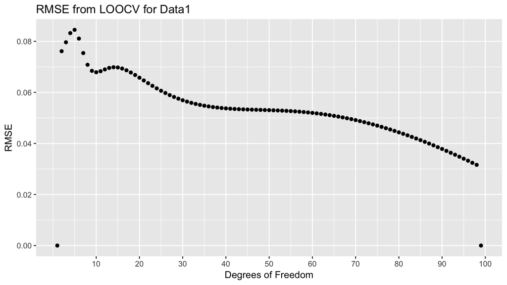

```r
ggplot(errorTableData1, aes(DF, errorForDF)) +
  geom_point() +
  scale_x_continuous(breaks=c(10, 20, 30, 40, 50, 60, 70, 80, 90, 100)) +
  labs(title = "RMSE from LOOCV for Data1", x = "Degrees of Freedom", y = "RMSE")
```

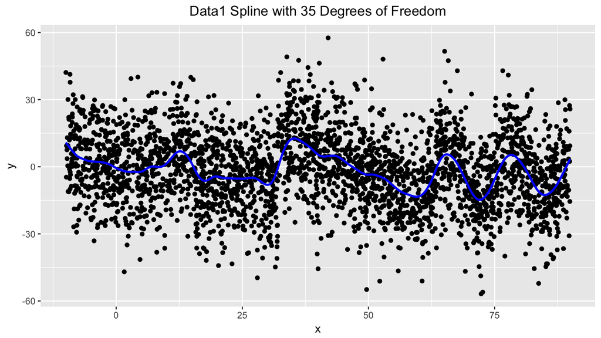

```r
thirtyFive <- smooth.spline(data1$x, data1$y, df=35) %>%
  broom::augment() %>%
  ggplot(aes(x = data1$x)) +
  geom_point(aes(y = data1$y)) +
  geom_line(aes(y=.fitted), col="blue", size=1) +
  labs(title = "Data1 Spline with 35 Degrees of Freedom", x = "x", y = "y") +
  theme(plot.title = element_text(hjust = 0.5))
thirtyFive
```